# Statistical model

## Statistical model

$$\textrm{outcome}_i = \textrm{model} + \textrm{error}_i$$

- A simple linear regression model: $y_i = \beta_0 + \beta_1 x_i + \epsilon_i$
- A non-linear regression model: $y_i = f(x_i) + \epsilon_i$
- $\cdots$

## Modeling

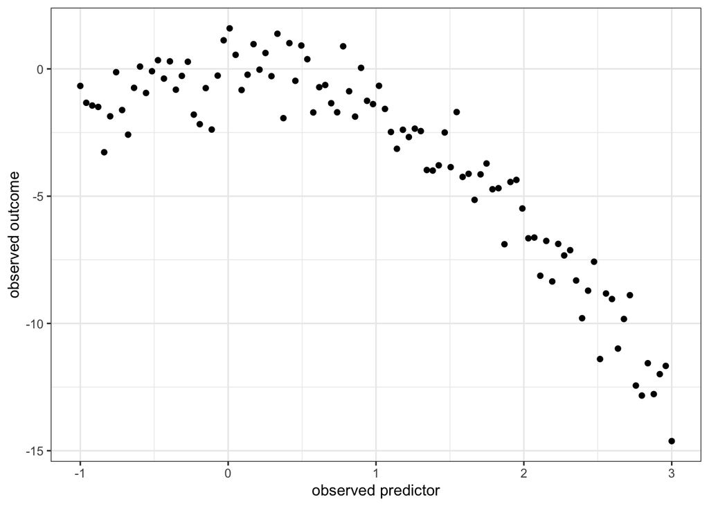

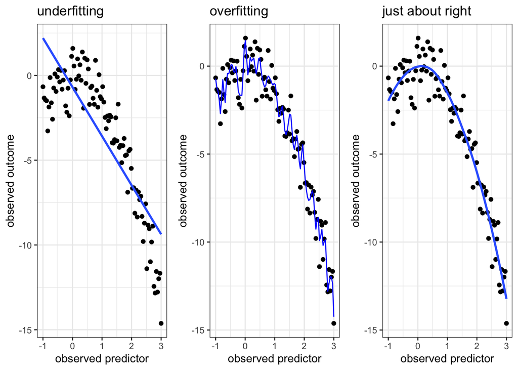

## Measuring the “Fit” of the Model

- Calculating “Error”
- A deviation is the difference between the mean and an actual data point.
- errors can be calculated by taking each value and subtracting the fit from it:
  $$\textrm{error}_i = \textrm{observed}_i - \textrm{fitted value}_i$$

## Mean model

$$\textrm{outcome}_i = \textrm{mean} + \textrm{error}_i$$

- What we assume?
  - We observe the values varying around the mean.
- How do we estimate the mean?
  - We use the sample mean – the sum of all scores divided by the number of scores.
- Your “prediction” for the next observation is simply the sample mean.
- Why does it make sense?
  - The mean is also the value from which the (squared) scores deviate least.

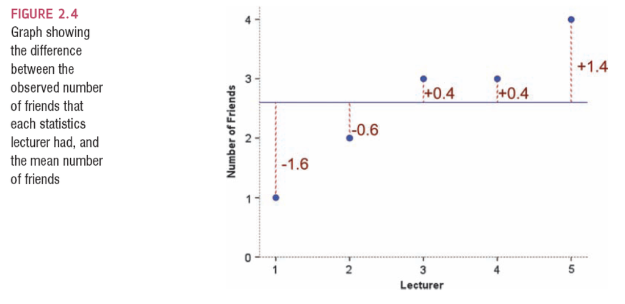

## Why squared?

- We could just take the error between the mean and the data and add them, but:

| Score | Mean | Deviation |
| --- | --- | --- |
| 1 | 2.6 | -1.6 |
| 2 | 2.6 | -0.6 |
| 3 | 2.6 | 0.4 |
| 3 | 2.6 | 0.4 |
| 4 | 2.6 | 1.4 |

Total error is: $-1.6 -0.6 + 0.4 + 0.4 + 1.4 = 0$.

## Sum of Squared Errors

- We could add the deviations to find out the total error.
- Deviations cancel out because some are positive and others negative.
- Therefore, we square each deviation.
- If we add these squared deviations we get the sum of squared errors (SS).

| Score | Mean | Deviation | Squared Deviation |
| --- | --- | --- | --- |
| 1 | 2.6 | -1.6 | 2.56 |
| 2 | 2.6 | -0.6 | 0.36 |
| 3 | 2.6 | 0.4 | 0.16 |
| 3 | 2.6 | 0.4 | 0.16 |
| 4 | 2.6 | 1.4 | 1.96 |

SS: $2.56 + 0.36 + 0.16 + 0.16 + 1.96 = 5.20$.

## Variance

- The sum of squares is a good measure of overall variability, but is dependent on the number of scores.
- We calculate the average variability by dividing by the number of scores ($n$).
- This value is called the variance ($s^2$).

$$\textrm{variance } s^2 = \frac{SS}{N-1} = \frac{\sum_{i=1}^{N} (x_i - \bar{x})^2}{N-1}$$

- We divide by $N-1$ – it is called *degree of freedom* (DF).

## Note

- When $N$ is very large, it makes little difference whether we use $N$ or $N-1$.
- In general statistical model setting, we use
  $$\frac{SS}{DF} = \frac{\sum_{i=1}^{N} (y_i - \hat{f}(x_i))^2}{DF}$$
  and this is a measure of variability of $y_i$ around $f(x_i)$.
- This is called *Mean Squared Error* (MSE).

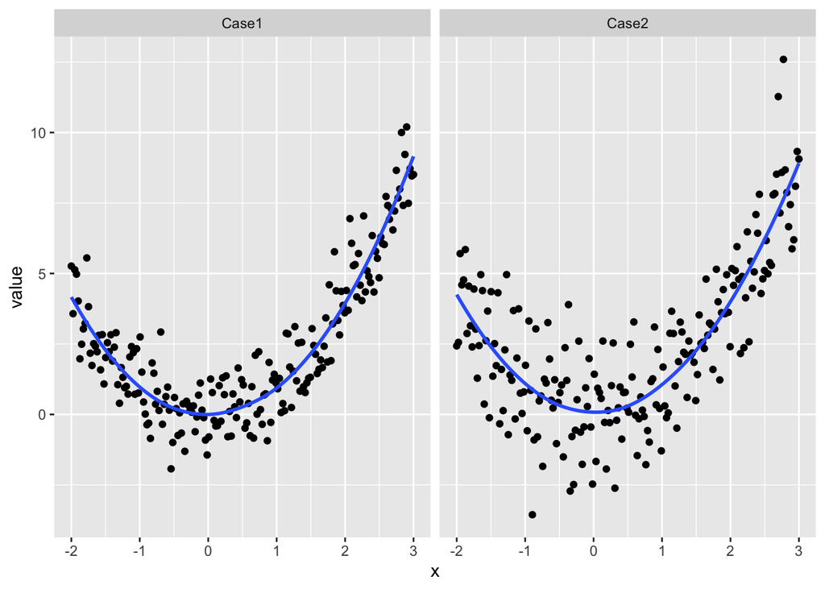

## Standard Deviation

- The variance has one problem: it is measured in units squared.
- This isn’t a very meaningful metric so we take the square root value.
- This is the standard deviation ($s$).

$$s = \sqrt{\frac{SS}{N-1} = \frac{\sum_{i=1}^{N} (x_i - \bar{x})^2}{N-1}}$$

- Similarly, we also take the square root of MSE – RMSE (Root Mean Squared Error).
  - This metric is often used as a key performance measure to compare different models.

## Population and Samples

- Population
  - The collection of units (be they people, plankton, plants, cities, suicidal authors, etc.) to which we want to generalize a set of findings or a statistical model
- Sample
  - A smaller (but hopefully representative) collection of units from a population used to determine truths about that population

Statistics is about how to use sample to learn about population.

## An example – a (typical) building energy consumption pattern

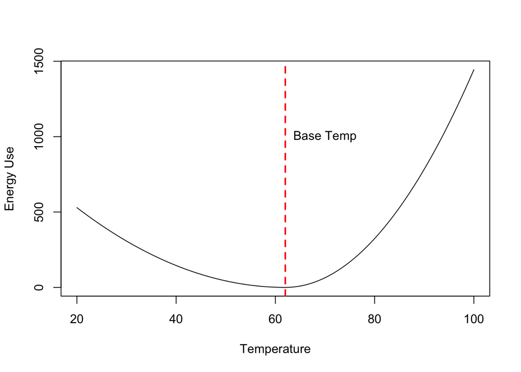

## Observed data

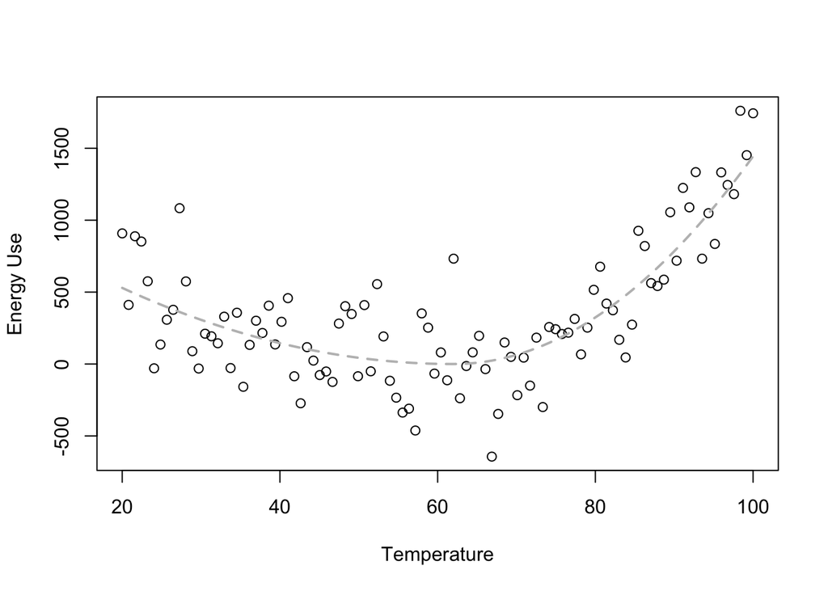

## Fitted

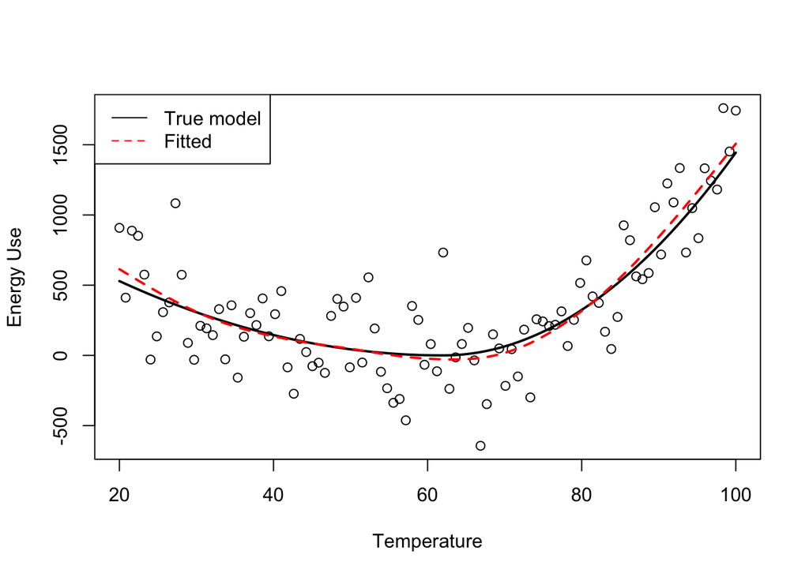

## Confidence Intervals (CI)

- An interval estimated from the observed data, that might contain the true value of an unknown population parameter.
- The sample mean calculated from a sample of size $n$ is approximately normal under random sampling:
  $$\bar{X} \sim N \left(\mu, \frac{\sigma^2}{n} \right)$$

## A simple example

(No worry if you don’t know how to read the code)

- We have a group of 10000 people whose average `age` is 49.52 and standard deviation 28.81.
- If we choose a sample of size 100, the sample mean age varies:

```r
mean(sample(age, 100))
```

```
## [1] 52.58787
```

```r
mean(sample(age, 100))
```

```
## [1] 48.04008
```

- So let’s repeat 10000 times and store it as `xbar`.

```r
xbar <- replicate(10000, mean(sample(age, 100)))
```

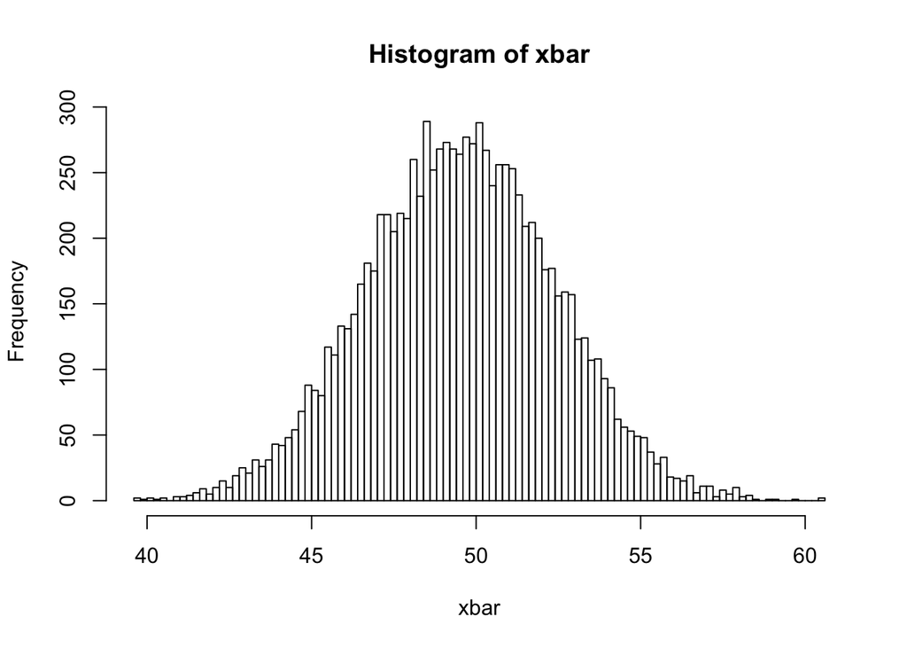

```r
mean(xbar)
```

```
## [1] 49.54076
```

```r
sd(xbar)
```

```
## [1] 2.870483
```

```r
28.81 / sqrt(100) # sigma / sqrt(n)
```

```
## [1] 2.881
```

## Test Statistics

- A statistic for which the frequency of particular values is known; its sampling distribution under the null hypothesis must be calculable (at least approximately).
- Often defined as a ratio of signal to noise:
  $$\textrm{test statistic} =
  \frac{\textrm{variance explained by the model}}{\textrm{variance not explained by the model}} =
  \frac{\textrm{effect}}{\textrm{error}}$$

## One- and Two-Tailed Tests

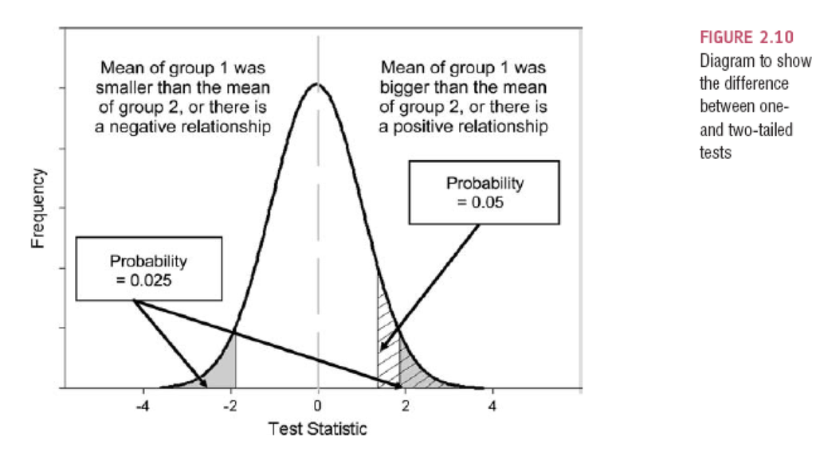

## Type I and Type II Errors

- Type I error
  - occurs when we believe that there is a genuine effect in our population when, in fact, there isn’t (i.e., false positive)
  - The probability is the $\alpha$-level (usually .05)
- Type II error
  - occurs when we believe that there is no effect in the population when, in reality, there is (i.e., false negative)
  - The probability is the $\beta$-level (often .2)